# Applying GBDT

#### Response Coding:

Response coding is a technique to represent the categorical data. In this technique, we represent the probability of the data point belonging to a particular class given a category.

reference:https://medium.com/@thewingedwolf.winterfell/response-coding-for-categorical-data-7bb8916c6dc1#

#### Example

[figure not shown]

```python
%matplotlib inline
import warnings
warnings.filterwarnings("ignore")

import sqlite3
import pandas as pd
import numpy as np
import nltk
import string
import matplotlib.pyplot as plt
import seaborn as sns
from sklearn.feature_extraction.text import TfidfTransformer
from sklearn.feature_extraction.text import TfidfVectorizer

from sklearn.feature_extraction.text import CountVectorizer
from sklearn.metrics import confusion_matrix
from sklearn import metrics
from sklearn.metrics import roc_curve, auc
from nltk.stem.porter import PorterStemmer

import re
import string
from nltk.corpus import stopwords
from nltk.stem import PorterStemmer
from nltk.stem.wordnet import WordNetLemmatizer

from gensim.models import Word2Vec
from gensim.models import KeyedVectors
import pickle

from tqdm import tqdm
import os

#from plotly import plotly
import plotly.offline as offline
import plotly.graph_objs as go
from collections import Counter
```

```python
from google.colab import drive
drive.mount('/content/drive')
```

```python
import nltk
from nltk.sentiment.vader import SentimentIntensityAnalyzer

# import nltk
nltk.download('vader_lexicon')

sid = SentimentIntensityAnalyzer()

for_sentiment = 'a person is a person no matter how small dr seuss i teach the smallest students with the biggest enthusiasm \
for learning my students learn in many different ways using all of our senses and multiple intelligences i use a wide range\
of techniques to help all my students succeed students in my class come from a variety of different backgrounds which makes\
for wonderful sharing of experiences and cultures including native americans our school is a caring community of successful \
learners which can be seen through collaborative student project based learning in and out of the classroom kindergarteners \
in my class love to work with hands on materials and have many different opportunities to practice a skill before it is\
mastered having the social skills to work cooperatively with friends is a crucial aspect of the kindergarten curriculum\
montana is the perfect place to learn about agriculture and nutrition my students love to role play in our pretend kitchen\
in the early childhood classroom i have had several kids ask me can we try cooking with real food i will take their idea \
and create common core cooking lessons where we learn important math and writing concepts while cooking delicious healthy \
food for snack time my students will have a grounded appreciation for the work that went into making the food and knowledge \
of where the ingredients came from as well as how it is healthy for their bodies this project would expand our learning of \
nutrition and agricultural cooking recipes by having us peel our own apples to make homemade applesauce make our own bread \
and mix up healthy plants from our classroom garden in the spring we will also create our own cookbooks to be printed and \
shared with families students will gain math and literature skills as well as a life long enjoyment for healthy cooking \
nannan'
ss = sid.polarity_scores(for_sentiment)

for k in ss:
    print('{0}: {1}, '.format(k, ss[k]), end='')

# we can use these 4 things as features/attributes (neg, neu, pos, compound)
# neg: 0.0, neu: 0.753, pos: 0.247, compound: 0.93
```

```
neg: 0.01, neu: 0.745, pos: 0.245, compound: 0.9975,
```

# 1. GBDT (xgboost/lightgbm)

## 1.1 Loading Data

```python
import pandas
data = pandas.read_csv('/content/drive/MyDrive/preprocessed_data.csv',nrows=50000)
data.columns
```

```
Index(['school_state', 'teacher_prefix', 'project_grade_category',
       'teacher_number_of_previously_posted_projects', 'project_is_approved',
       'clean_categories', 'clean_subcategories', 'essay', 'price'],
      dtype='object')
```

```python
print(data['essay'].head(1).values)
```

```
['i fortunate enough use fairy tale stem kits classroom well stem journals students really enjoyed i would love implement lakeshore stem kits classroom next school year provide excellent engaging stem lessons my students come variety backgrounds including language socioeconomic status many not lot e…
```

```python
import re

def decontracted(phrase):
    # specific
    phrase = re.sub(r"won't", "will not", phrase)
    phrase = re.sub(r"can\'t", "can not", phrase)

    # general
    phrase = re.sub(r"n\'t", " not", phrase)
    phrase = re.sub(r"\'re", " are", phrase)
    phrase = re.sub(r"\'s", " is", phrase)
    phrase = re.sub(r"\'d", " would", phrase)
    phrase = re.sub(r"\'ll", " will", phrase)
    phrase = re.sub(r"\'t", " not", phrase)
    phrase = re.sub(r"\'ve", " have", phrase)
    phrase = re.sub(r"\'m", " am", phrase)
    return phrase
```

```python
# https://gist.github.com/sebleier/554280
# we are removing the words from the stop words list: 'no', 'nor', 'not'
#added nan to the stop words
stopwords= ['i', 'me', 'my', 'myself', 'we', 'our', 'ours', 'ourselves', 'you', "you're", "you've",\
            "you'll", "you'd", 'your', 'yours', 'yourself', 'yourselves', 'he', 'him', 'his', 'himself', \
            'she', "she's", 'her', 'hers', 'herself', 'it', "it's", 'its', 'itself', 'they', 'them', 'their',\
            'theirs', 'themselves', 'what', 'which', 'who', 'whom', 'this', 'that', "that'll", 'these', 'those', \
            'am', 'is', 'are', 'was', 'were', 'be', 'been', 'being', 'have', 'has', 'had', 'having', 'do', 'does', \
            'did', 'doing', 'a', 'an', 'the', 'and', 'but', 'if', 'or', 'because', 'as', 'until', 'while', 'of', \
            'at', 'by', 'for', 'with', 'about', 'against', 'between', 'into', 'through', 'during', 'before', 'after',\
            'above', 'below', 'to', 'from', 'up', 'down', 'in', 'out', 'on', 'off', 'over', 'under', 'again', 'further',\
            'then', 'once', 'here', 'there', 'when', 'where', 'why', 'how', 'all', 'any', 'both', 'each', 'few', 'more',\
            'most', 'other', 'some', 'such', 'only', 'own', 'same', 'so', 'than', 'too', 'very', \
            's', 't', 'can', 'will', 'just', 'don', "don't", 'should', "should've", 'now', 'd', 'll', 'm', 'o', 're', \
            've', 'y', 'ain', 'aren', "aren't", 'couldn', "couldn't", 'didn', "didn't", 'doesn', "doesn't", 'hadn',\
            "hadn't", 'hasn', "hasn't", 'haven', "haven't", 'isn', "isn't", 'ma', 'mightn', "mightn't", 'mustn',\
            "mustn't", 'needn', "needn't", 'shan', "shan't", 'shouldn',"nan","nannan", "shouldn't", 'wasn', "wasn't", 'weren', "weren't", \
            'won', "won't", 'wouldn', "wouldn't"]
```

```python
# Combining all the above stundents
from tqdm import tqdm
def preprocess_text(text_data):
    preprocessed_text = []
    # tqdm is for printing the status bar
    for sentance in tqdm(text_data):
        sent = decontracted(sentance)
        sent = sent.replace('\\r', ' ')
        sent = sent.replace('\\n', ' ')
        sent = sent.replace('\\"', ' ')
        sent = re.sub('[^A-Za-z0-9]+', ' ', sent)
        # https://gist.github.com/sebleier/554280
        sent = ' '.join(e for e in sent.split() if e.lower() not in stopwords)
        preprocessed_text.append(sent.lower().strip())
    return preprocessed_text
```

```python
preprocessed_essays = preprocess_text(data['essay'].values)
```

```python
data['preprocessed_essays'] = preprocessed_essays
print(data['preprocessed_essays'].head(1).values)
```

```
['fortunate enough use fairy tale stem kits classroom well stem journals students really enjoyed would love implement lakeshore stem kits classroom next school year provide excellent engaging stem lessons students come variety backgrounds including language socioeconomic status many not lot experien…
```

## Performing Sentiment Analysis: Sentiment_score for preprocesssed essays

```python
# Sentiment Analysis on 'essay'
sid    = SentimentIntensityAnalyzer()

negative_sentiments = []
positive_sentiments = []
neutral_sentiments = []
compound_sentiments = []

for i in tqdm(data['preprocessed_essays']):
    ss = sid.polarity_scores(i)
    negative_sentiments.append(ss['neg'])
    positive_sentiments.append(ss['pos'])
    neutral_sentiments.append(ss['neu'])
    compound_sentiments.append(ss['compound'])

#Append these sentiments columns/freatures to preprocessed dataframe
data['negative_sent'] = negative_sentiments
data['positive_sent'] = positive_sentiments
data['neutral_sent'] = neutral_sentiments
data['compound_sent'] = compound_sentiments

data.head(1)
```

|  | school_state | teacher_prefix | project_grade_category | teacher_number_of_previously_posted_projects | project_is_approved | clean_categories | clean_subcategories | essay | price | preprocessed_essays | negative_sent | positive_sent | neutral_sent | compound_sent |
| --- | --- | --- | --- | --- | --- | --- | --- | --- | --- | --- | --- | --- | --- | --- |
| 0 | ca | mrs | grades_prek_2 | 53 | 1 | math_science | appliedsciences health_lifescience | i fortunate enough use fairy tale stem kits cl... | 725.05 | fortunate enough use fairy tale stem kits clas... | 0.013 | 0.214 | 0.773 | 0.9867 |

## 1.2 Splitting data into Train and cross validation(or test): Stratified Sampling

```python
y = data['project_is_approved'].values #class label
X = data.drop(['project_is_approved'], axis=1) #data points
X.head(1)
```

|  | school_state | teacher_prefix | project_grade_category | teacher_number_of_previously_posted_projects | clean_categories | clean_subcategories | essay | price | preprocessed_essays | negative_sent | positive_sent | neutral_sent | compound_sent |
| --- | --- | --- | --- | --- | --- | --- | --- | --- | --- | --- | --- | --- | --- |
| 0 | ca | mrs | grades_prek_2 | 53 | math_science | appliedsciences health_lifescience | i fortunate enough use fairy tale stem kits cl... | 725.05 | fortunate enough use fairy tale stem kits clas... | 0.013 | 0.214 | 0.773 | 0.9867 |

```python
from sklearn.model_selection import train_test_split
x_train,x_test,y_train,y_test=train_test_split(
    X,
    y,
    test_size=0.2,
    random_state=42,
    stratify=y)
print("x_train: ",x_train.shape)
print("x_test : ",x_test.shape)
print("y_train: ",y_train.shape)
print("y_test : ",y_test.shape)
```

```
x_train:  (40000, 13)
x_test :  (10000, 13)
y_train:  (40000,)
y_test :  (10000,)
```

## 1.3 Make Data Model Ready: encoding eassay

### TF-IDF : Encoding Essay

```python
vectorizer_essay_tfidf = TfidfVectorizer(min_df=10)
vectorizer_essay_tfidf.fit(x_train['preprocessed_essays'].values) # fit has to happen only on train data

# we use the fitted CountVectorizer to convert the text to vector
X_train_essay_tfidf = vectorizer_essay_tfidf.transform(x_train['preprocessed_essays'].values)
X_test_essay_tfidf = vectorizer_essay_tfidf.transform(x_test['preprocessed_essays'].values)

print("After vectorization")
print("Shape of matrix after TF-IDF -> essays: x_train:",X_train_essay_tfidf.shape)
print("Shape of matrix after TF-IDF -> essays: x_test:",X_test_essay_tfidf.shape )
```

```
After vectorization
Shape of matrix after TF-IDF -> essays: x_train: (40000, 10982)
Shape of matrix after TF-IDF -> essays: x_test: (10000, 10982)
```

### TF-IDF W2V: Encoding Essay

```python
with open('/content/drive/MyDrive/glove_vectors', 'rb') as f:
    model = pickle.load(f)
    glove_words =  set(model.keys())
```

```python
# we are converting a dictionary with word as a key, and the idf as a value
dictionary = dict(zip( vectorizer_essay_tfidf.get_feature_names(), list( vectorizer_essay_tfidf.idf_)))
tfidf_words = set( vectorizer_essay_tfidf.get_feature_names())


def tfidf_w2v(x):
    """Compute tfidf weighted Word2Vec for each review"""

    tfidf_w2v_vectors = []; # the avg-w2v for each sentence/review is stored in this list

    for sentence in tqdm(x): # for each review/sentence
        vector = np.zeros(300) # as word vectors are of zero length
        tf_idf_weight =0; # num of words with a valid vector in the sentence/review
        for word in sentence.split(): # for each word in a review/sentence
            if (word in glove_words) and (word in tfidf_words):
                vec = model[word] # getting the vector for each word
                # here we are multiplying idf value(dictionary[word]) and the tf value((sentence.count(word)/len(sentence.split())))
                tf_idf = dictionary[word]*(sentence.count(word)/len(sentence.split())) # getting the tfidf value for each word
                vector += (vec * tf_idf) # calculating tfidf weighted w2v
                tf_idf_weight += tf_idf
        if tf_idf_weight != 0:
            vector /= tf_idf_weight
        tfidf_w2v_vectors .append(vector)



    return tfidf_w2v_vectors
```

```python
x_train_tfidf_w2v_essay_vectors = tfidf_w2v(x_train['preprocessed_essays'].values)
```

```python
x_test_tfidf_w2v_essay_vectors = tfidf_w2v(x_test['preprocessed_essays'].values)
```

## 1.4 Make Data Model Ready: encoding numerical, categorical features

Response encoding: We represent the probability of the data point belonging to a particular class given a category.

reference:

- https://medium.com/@thewingedwolf.winterfell/response-coding-for-categorical-data-7bb8916c6dc1
- https://www.kaggle.com/paulrohan2020/xgboost-on-donor-choose#1.4-Make-Data-Model-Ready:-encoding-categorical-features

```python
def response_encoding_fit(x_train_feature_total, x_train_feature_0, x_train_feature_1):

    """ Function to response-encode categorical features - fit()

Basically generate three Counter dict for total of a feature and
feature_when_class_is_0 and feature_when_class_is_1

args:
  x_train_feature_total => df of the form (from Training data) => x['feature_name']
  x_train_feature_0 => of form (from Training data) => x.loc[x['project_is_approved']== 0]['feature_name']
  x_train_feature_1 => of form (from Training data) => x.loc[x['project_is_approved']== 1]['feature_name']

  returns:
     dictionary (dict) => Of form => Counter({'ca': 53, 'in': 21,... }) for "school_state" feature
"""

    feature_counter_total = Counter()
    feature_counter_total.update(i for i in x_train_feature_total)

    feature_counter_0 = Counter()  # Create a dict variable to act as a Counter
    feature_counter_0.update(i for i in x_train_feature_0)   # adding values to the Counter from x_train_feature_0

    for i in feature_counter_total:
        if i not in feature_counter_0:
            feature_counter_0[i] = 0

    feature_counter_1 = Counter()
    feature_counter_1.update(i for i in x_train_feature_1)

    for i in feature_counter_total:
        if i not in feature_counter_1:
            feature_counter_1[i] = 0


    return feature_counter_total, feature_counter_0, feature_counter_1



def response_encoding_transform(x_feature_train, feature_counter_total, feature_counter_0, feature_counter_1):
    feature_proba_list_0 = []
    feature_proba_list_1 = []

    for i in x_feature_train:

        if i in feature_counter_total.keys():
            proba_0 = feature_counter_0.get(i)/feature_counter_total.get(i)
            proba_1 = feature_counter_1.get(i)/feature_counter_total.get(i)

            feature_proba_list_0.append(proba_0)
            feature_proba_list_1.append(proba_1)

        else:

            feature_proba_list_0.append(0.5)
            feature_proba_list_1.append(0.5)
            # Have to convert to array so I can invoke reshape() on these

    feature_proba_array_0 = np.array(feature_proba_list_0)
    feature_proba_array_1 = np.array(feature_proba_list_1)

    return feature_proba_array_0.reshape(-1,1), feature_proba_array_1.reshape(-1,1)
```

```python
# make a new dataframe for all the categorical feature from only the train dataset
# Categorial Featues are => school_state, teacher_prefix, project_grade_category, clean_categoris, clean_subcategories

df_cat_train_before_response_coding = pd.DataFrame(y_train, columns=['project_is_approved'])
df_cat_train_before_response_coding['school_state'] = x_train['school_state'].values
df_cat_train_before_response_coding['teacher_prefix'] = x_train['teacher_prefix'].values
df_cat_train_before_response_coding['project_grade_category'] = x_train['project_grade_category'].values
df_cat_train_before_response_coding['clean_categories'] = x_train['clean_categories'].values
df_cat_train_before_response_coding['clean_subcategories'] = x_train['clean_subcategories'].values
df_cat_train_before_response_coding.head(2)
```

|  | project_is_approved | school_state | teacher_prefix | project_grade_category | clean_categories | clean_subcategories |
| --- | --- | --- | --- | --- | --- | --- |
| 0 | 1 | fl | ms | grades_prek_2 | literacy_language | literacy |
| 1 | 1 | ca | ms | grades_9_12 | appliedlearning | charactereducation extracurricular |

### Response encoding: school state

```python
x_train_feature_total = df_cat_train_before_response_coding['school_state']
x_train_feature_0 = df_cat_train_before_response_coding.loc[df_cat_train_before_response_coding['project_is_approved']==0]['school_state']
x_train_feature_1 = df_cat_train_before_response_coding.loc[df_cat_train_before_response_coding['project_is_approved']==1]['school_state']

school_state_counter_total, school_state_counter_0, school_state_counter_1 = response_encoding_fit(x_train_feature_total, x_train_feature_0, x_train_feature_1 )

X_train_school_state_response_proba_0, X_train_school_state_response_proba_1 = response_encoding_transform(x_train['school_state'], school_state_counter_total, school_state_counter_0, school_state_counter_1)

X_test_school_state_response_proba_0, X_test_school_state_response_proba_1 = response_encoding_transform(x_test['school_state'], school_state_counter_total, school_state_counter_0, school_state_counter_1)

print(np.mean(X_train_school_state_response_proba_0, axis=0))
print(X_train_school_state_response_proba_0.shape, y_train.shape)
print(X_test_school_state_response_proba_0.shape, y_test.shape)
```

```
[0.16015]
(40000, 1) (40000,)
(10000, 1) (10000,)
```

### Response encoding: teacher_prefix

```python
x_train_feature_total = df_cat_train_before_response_coding['teacher_prefix']
x_train_feature_0 = df_cat_train_before_response_coding.loc[df_cat_train_before_response_coding['project_is_approved']==0]['teacher_prefix']
x_train_feature_1 = df_cat_train_before_response_coding.loc[df_cat_train_before_response_coding['project_is_approved']==1]['teacher_prefix']

teacher_prefix_counter_total, teacher_prefix_counter_0, teacher_prefix_counter_1 = response_encoding_fit(x_train_feature_total, x_train_feature_0, x_train_feature_1 )

X_train_teacher_prefix_response_proba_0, X_train_teacher_prefix_response_proba_1 = response_encoding_transform(x_train['teacher_prefix'], teacher_prefix_counter_total, teacher_prefix_counter_0, teacher_prefix_counter_1)

X_test_teacher_prefix_response_proba_0, X_test_teacher_prefix_response_proba_1 = response_encoding_transform(x_test['teacher_prefix'], teacher_prefix_counter_total, teacher_prefix_counter_0, teacher_prefix_counter_1)

print(np.mean(X_train_teacher_prefix_response_proba_0, axis=0))
print(X_train_teacher_prefix_response_proba_0.shape, y_train.shape)
print(X_test_teacher_prefix_response_proba_0.shape, y_test.shape)
```

```
[0.16015]
(40000, 1) (40000,)
(10000, 1) (10000,)
```

### Response encoding: project_grade_category

```python
x_train_feature_total = df_cat_train_before_response_coding['project_grade_category']
x_train_feature_0 = df_cat_train_before_response_coding.loc[df_cat_train_before_response_coding['project_is_approved']==0]['project_grade_category']
x_train_feature_1 = df_cat_train_before_response_coding.loc[df_cat_train_before_response_coding['project_is_approved']==1]['project_grade_category']

project_grade_category_counter_total, project_grade_category_counter_0, project_grade_category_counter_1 = response_encoding_fit(x_train_feature_total, x_train_feature_0, x_train_feature_1 )

X_train_project_grade_category_response_proba_0, X_train_project_grade_category_response_proba_1 = response_encoding_transform(x_train['project_grade_category'], project_grade_category_counter_total, project_grade_category_counter_0, project_grade_category_counter_1)

X_test_project_grade_category_response_proba_0, X_test_project_grade_category_response_proba_1 = response_encoding_transform(x_test['project_grade_category'], project_grade_category_counter_total, project_grade_category_counter_0, project_grade_category_counter_1)

print(np.mean(X_train_project_grade_category_response_proba_0, axis=0))
print(X_train_project_grade_category_response_proba_0.shape, y_train.shape)
print(X_test_project_grade_category_response_proba_0.shape, y_test.shape)
```

```
[0.16015]
(40000, 1) (40000,)
(10000, 1) (10000,)
```

### Response encoding: clean_categories

```python
x_train_feature_total = df_cat_train_before_response_coding['clean_categories']
x_train_feature_0 = df_cat_train_before_response_coding.loc[df_cat_train_before_response_coding['project_is_approved']==0]['clean_categories']
x_train_feature_1 = df_cat_train_before_response_coding.loc[df_cat_train_before_response_coding['project_is_approved']==1]['clean_categories']

clean_categories_counter_total, clean_categories_counter_0, clean_categories_counter_1 = response_encoding_fit(x_train_feature_total, x_train_feature_0, x_train_feature_1 )

X_train_clean_categories_response_proba_0, X_train_clean_categories_response_proba_1 = response_encoding_transform(x_train['clean_categories'], clean_categories_counter_total, clean_categories_counter_0, clean_categories_counter_1)

X_test_clean_categories_response_proba_0, X_test_clean_categories_response_proba_1 = response_encoding_transform(x_test['clean_categories'], clean_categories_counter_total, clean_categories_counter_0, clean_categories_counter_1)

print(np.mean(X_train_clean_categories_response_proba_0, axis=0))
print(X_train_clean_categories_response_proba_0.shape, y_train.shape)
print(X_test_clean_categories_response_proba_0.shape, y_test.shape)
```

```
[0.16015]
(40000, 1) (40000,)
(10000, 1) (10000,)
```

### Response encoding: clean_subcategories

```python
x_train_feature_total = df_cat_train_before_response_coding['clean_subcategories']
x_train_feature_0 = df_cat_train_before_response_coding.loc[df_cat_train_before_response_coding['project_is_approved']==0]['clean_subcategories']
x_train_feature_1 = df_cat_train_before_response_coding.loc[df_cat_train_before_response_coding['project_is_approved']==1]['clean_subcategories']

clean_subcategories_counter_total, clean_subcategories_counter_0, clean_subcategories_counter_1 = response_encoding_fit(x_train_feature_total, x_train_feature_0, x_train_feature_1 )

X_train_clean_subcategories_response_proba_0, X_train_clean_subcategories_response_proba_1 = response_encoding_transform(x_train['clean_subcategories'], clean_subcategories_counter_total, clean_subcategories_counter_0, clean_subcategories_counter_1)

X_test_clean_subcategories_response_proba_0, X_test_clean_subcategories_response_proba_1 = response_encoding_transform(x_test['clean_subcategories'], clean_subcategories_counter_total, clean_subcategories_counter_0, clean_subcategories_counter_1)

print(np.mean(X_train_clean_subcategories_response_proba_0, axis=0))
print(X_train_clean_subcategories_response_proba_0.shape, y_train.shape)
print(X_test_clean_subcategories_response_proba_0.shape, y_test.shape)
```

```
[0.16015]
(40000, 1) (40000,)
(10000, 1) (10000,)
```

### Normalizing numerical data: Price

```python
from sklearn.preprocessing import Normalizer
normalizer = Normalizer()

normalizer.fit(x_train['price'].values.reshape(1,-1))
# After normalization reshape again to (-1, 1) i.e. this time unknown rows (i.e. leaving it to Numpy to decide), and specifying I need 1 column
X_train_price_normalized = normalizer.transform(x_train['price'].values.reshape(1,-1)).reshape(-1,1)
X_test_price_normalized = normalizer.transform(x_test['price'].values.reshape(1,-1)).reshape(-1,1)



print("After Normalizing")
print(X_train_price_normalized.shape, y_train.shape)
#print(X_cv_price_norm.shape, y_cv.shape)
print(X_test_price_normalized.shape, y_test.shape)
print("="*100)
```

```
After Normalizing
(40000, 1) (40000,)
(10000, 1) (10000,)
====================================================================================================
```

### Normalizing numerical data: teacher_number_of_previously_posted_projects

```python
from sklearn.preprocessing import Normalizer
normalizer = Normalizer()

normalizer.fit(x_train['teacher_number_of_previously_posted_projects'].values.reshape(1,-1))

X_train_teacher_previous_proj_normalized = normalizer.transform(x_train['teacher_number_of_previously_posted_projects'].values.reshape(1,-1))
#X_cv_teacher_previous_proj_normalized= normalizer.transform(X_cv['price'].values.reshape(1,-1))
X_test_teacher_previous_proj_normalized = normalizer.transform(x_test['teacher_number_of_previously_posted_projects'].values.reshape(1,-1))

# After normalization reshape again to (-1, 1) i.e. this time unknown rows (i.e. leaving it to Numpy to decide), and specifying I need 1 column
X_train_teacher_previous_proj_normalized = X_train_teacher_previous_proj_normalized.reshape(-1, 1)

X_test_teacher_previous_proj_normalized = X_test_teacher_previous_proj_normalized.reshape(-1, 1)


print("After Normalizing")
print(X_train_teacher_previous_proj_normalized.shape, y_train.shape)
#print(X_cv_price_norm.shape, y_cv.shape)
print(X_test_teacher_previous_proj_normalized.shape, y_test.shape)
```

```
After Normalizing
(40000, 1) (40000,)
(10000, 1) (10000,)
```

### Sentiment scores: preprocessed_essays

```python
sentiment_train_negative_sent=x_train['negative_sent'].values.reshape(-1,1)
sentiment_train_positive_sent=x_train['positive_sent'].values.reshape(-1,1)
sentiment_train_neutral_sent=x_train['neutral_sent'].values.reshape(-1,1)
sentiment_train_compound_sent=x_train['compound_sent'].values.reshape(-1,1)

sentiment_test_negative_sent=x_test['negative_sent'].values.reshape(-1,1)
sentiment_test_positive_sent=x_test['positive_sent'].values.reshape(-1,1)
sentiment_test_neutral_sent=x_test['neutral_sent'].values.reshape(-1,1)
sentiment_test_compound_sent=x_test['compound_sent'].values.reshape(-1,1)
```

## Merging all vectorized data

```python
from scipy.sparse import hstack

x_train_set1 = hstack((
    X_train_school_state_response_proba_0,
    X_train_teacher_prefix_response_proba_0 ,
    X_train_project_grade_category_response_proba_0 ,
    X_train_clean_categories_response_proba_0 ,
    X_train_clean_subcategories_response_proba_0,
    X_train_price_normalized,
    X_train_teacher_previous_proj_normalized,
    X_train_essay_tfidf,
    sentiment_train_negative_sent,
    sentiment_train_positive_sent,
    sentiment_train_neutral_sent,
    sentiment_train_compound_sent)).tocsr()

x_test_set1 = hstack((
    X_test_school_state_response_proba_0,
    X_test_teacher_prefix_response_proba_0 ,
    X_test_project_grade_category_response_proba_0 ,
    X_test_clean_categories_response_proba_0 ,
    X_test_clean_subcategories_response_proba_0,
    X_test_price_normalized,
    X_test_teacher_previous_proj_normalized,
    X_test_essay_tfidf,
    sentiment_test_negative_sent,
    sentiment_test_positive_sent,
    sentiment_test_neutral_sent,
    sentiment_test_compound_sent)).tocsr()



print("Type of x_train_set1:",type(x_train_set1))
print("Type of x_test_set1:",type(x_test_set1))
print("Shape of x_train_set1:",x_train_set1.shape)
print("Shape of x_test_set1:",x_test_set1.shape)
```

```
Type of x_train_set1: <class 'scipy.sparse.csr.csr_matrix'>
Type of x_test_set1: <class 'scipy.sparse.csr.csr_matrix'>
Shape of x_train_set1: (40000, 10993)
Shape of x_test_set1: (10000, 10993)
```

### SET 2: categorical(response coding), numerical features + preprocessed_eassay (TFIDF W2V)

```python
from scipy.sparse import hstack
from scipy.sparse import coo_matrix



#x_train_set2 = hstack((coo_matrix(X_train_school_state_response_proba_0), coo_matrix(X_train_teacher_prefix_response_proba_0)))

#coo_matrix([[teach_0.get(i)] for i in test_x])

x_train_set2 = hstack((x_train_tfidf_w2v_essay_vectors,
    coo_matrix(X_train_school_state_response_proba_0),
    coo_matrix(X_train_teacher_prefix_response_proba_0),
    coo_matrix(X_train_project_grade_category_response_proba_0),
    coo_matrix(X_train_clean_categories_response_proba_0),
    coo_matrix(X_train_clean_subcategories_response_proba_0),
    X_train_price_normalized,
    X_train_teacher_previous_proj_normalized)).tocsr()



x_test_set2 = hstack((
    x_test_tfidf_w2v_essay_vectors,
    coo_matrix(X_test_school_state_response_proba_0),
    coo_matrix(X_test_teacher_prefix_response_proba_0),
    coo_matrix(X_test_project_grade_category_response_proba_0),
    coo_matrix(X_test_clean_categories_response_proba_0),
    coo_matrix(X_test_clean_subcategories_response_proba_0),
    X_test_price_normalized,
    X_test_teacher_previous_proj_normalized)).tocsr()


print("Type of x_train_set2:",type(x_train_set2))
print("Type of x_test_set2:",type(x_test_set2))
print("Shape of x_train_set2:",x_train_set2.shape)
print("Shape of x_test_set2:",x_test_set2.shape)
```

```
Type of x_train_set2: <class 'scipy.sparse.csr.csr_matrix'>
Type of x_test_set2: <class 'scipy.sparse.csr.csr_matrix'>
Shape of x_train_set2: (40000, 307)
Shape of x_test_set2: (10000, 307)
```

## 1.5 Appling Models on different kind of featurization as mentioned in the instructions

Apply GBDT on different kind of featurization as mentioned in the instructions  
For Every model that you work on make sure you do the step 2 and step 3 of instrucations

## SET1: The hyper paramter tuning using GridSearchCV

```python
from xgboost import XGBClassifier
from sklearn.metrics import roc_curve
from sklearn.model_selection import GridSearchCV
import matplotlib.pyplot as plt
from sklearn.metrics import roc_auc_score


xgb_clf_set1 = XGBClassifier()

parameters = { 'max_depth':[5,10],'eta':[0.0001, 0.001, 0.01, 0.1],'n_estimators': [30, 40, 50]}

clf1 = GridSearchCV(xgb_clf_set1, parameters, cv=3, scoring='roc_auc', verbose=1,return_train_score=True,n_jobs=-1)

clf1.fit(x_train_set1, y_train)


train_auc= clf1.cv_results_['mean_train_score']
train_auc_std= clf1.cv_results_['std_train_score']
cv_auc = clf1.cv_results_['mean_test_score']
cv_auc_std= clf1.cv_results_['std_test_score']

bestMaxdepth_1=clf1.best_params_['max_depth']
bestLearningRate_1 = clf1.best_params_['eta']
best_n_estimator =clf1.best_params_['n_estimators']
bestScore_1=clf1.best_score_

print("BEST MAX DEPTH: ",bestMaxdepth_1)
print("BEST MIN SAMPLES SPLIT:",bestLearningRate_1)
print("BEST n_estimator: ",best_n_estimator)
```

```
Fitting 3 folds for each of 24 candidates, totalling 72 fits
```

```
[Parallel(n_jobs=-1)]: Using backend LokyBackend with 2 concurrent workers.
[Parallel(n_jobs=-1)]: Done  46 tasks      | elapsed: 23.1min
[Parallel(n_jobs=-1)]: Done  72 out of  72 | elapsed: 38.3min finished
```

```
BEST MAX DEPTH:  10
BEST MIN SAMPLES SPLIT: 0.0001
BEST n_estimator:  50
```

```python
learning_rates = [0.0001, 0.001, 0.01, 0.1, 0.2]
n_estimators = [30, 40, 50, 60]

def get_auc_matrix(x_train, x_test, y_train, y_test ):

    train_auc_final_arr, test_auc_final_arr = [], []

    for l_rate in tqdm(learning_rates):
        train_auc_batch, test_auc_batch = [], []

        for num in n_estimators:
            # Below gives large number of warnings
            # xgb_clf = XGBClassifier(n_estimators=num, eta=l_rate, reg_alpha=0, reg_lambda=0, tree_method='gpu_hist')

            # below works after including eval_metric='mlogloss'
            # xgb_clf = XGBClassifier(n_estimators=num, eval_metric='mlogloss', learning_rate=l_rate, reg_alpha=0, reg_lambda=0, tree_method='gpu_hist')

            # Only changing the name of the parameter learning_rate to eta
            xgb_clf = XGBClassifier(n_estimators=num,eta=l_rate)

            xgb_clf.fit(x_train, y_train)

            # I have to predict probabilities (clf.predict_proba) instead of classes for calculating of ROC AUC score:
            y_train_predicted = xgb_clf.predict_proba(x_train)[:, 1]
            y_test_predicted = xgb_clf.predict_proba(x_test)[:, 1]

            train_auc = roc_auc_score(y_train, y_train_predicted)
            test_auc = roc_auc_score(y_test, y_test_predicted)

            train_auc_batch.append(train_auc)
            test_auc_batch.append(test_auc)

        train_auc_final_arr.append(train_auc_batch)
        test_auc_final_arr.append(test_auc_batch)

    return train_auc_final_arr, test_auc_final_arr


train_auc_final_arr_s1, test_auc_final_arr_s1 = get_auc_matrix(x_train_set1, x_test_set1, y_train, y_test)
```

### HeapMap for SET1

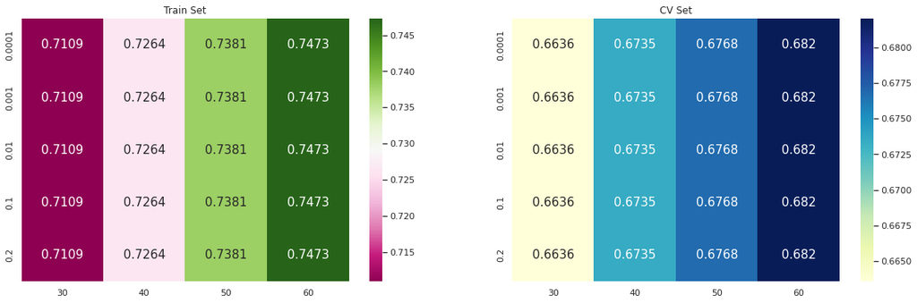

```python
import seaborn as sns; sns.set()
train_auc_final_df_s1 = pd.DataFrame(train_auc_final_arr_s1, columns=n_estimators, index=learning_rates)
test_auc_final_df_s1 = pd.DataFrame(test_auc_final_arr_s1, columns=n_estimators, index=learning_rates)
fig, ax = plt.subplots(1,2, figsize=(20,6))
sns.heatmap(train_auc_final_df_s1, annot = True, fmt='.4g', ax=ax[0],annot_kws={"size": 15},cmap="PiYG")
sns.heatmap(test_auc_final_df_s1, annot = True, fmt='.4g', ax=ax[1],annot_kws={"size": 15},cmap="YlGnBu")
ax[0].set_title('Train Set')
ax[1].set_title('CV Set')
plt.show()
```

### ROC Curve

Best Params from GridSearchCV with XGB for Set s1 {'eta': 0.0001, 'n_estimators': 50}

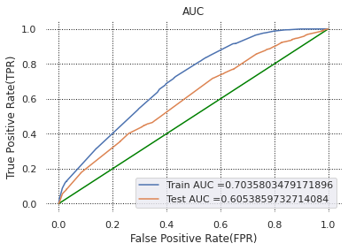

```python
xgb_clf1 = XGBClassifier(n_estimators=best_n_estimator, learning_rate=bestLearningRate_1, max_depth=bestMaxdepth_1)

xgb_clf1.fit(x_train_set1, y_train)

y_train_pred_set1=xgb_clf1.predict_proba(x_train_set1)[:,1]
predictions_train_set1=xgb_clf1.predict(x_train_set1)

y_test_pred_set1=xgb_clf1.predict_proba(x_test_set1)[:,1]
predictions_test_set1=xgb_clf1.predict(x_test_set1)


train_fpr1, train_tpr1, tr_thresholds1 = roc_curve(y_train, y_train_pred_set1)
test_fpr1, test_tpr1, te_thresholds1 = roc_curve(y_test, y_test_pred_set1)

ax = plt.subplot()

auc_set1_train=auc(train_fpr1, train_tpr1)
auc_set1_test=auc(test_fpr1, test_tpr1)

plt.plot([0, 1], [0, 1], color='green')
ax.plot(train_fpr1, train_tpr1, label="Train AUC ="+str(auc(train_fpr1, train_tpr1)))
ax.plot(test_fpr1, test_tpr1, label="Test AUC ="+str(auc(test_fpr1, test_tpr1)))
plt.legend()
plt.xlabel("False Positive Rate(FPR)")
plt.ylabel("True Positive Rate(TPR)")
plt.title("AUC")
plt.grid(b=True, which='major', color='k', linestyle=':')
ax.set_facecolor("white")
plt.show()
```

### Confusion Matrix: x_train_set1

```python
def predict(proba, threshould, fpr, tpr):
    t = threshould[np.argmax(tpr*(1-fpr))]
    # (tpr*(1-fpr)) will be maximum if your fpr is very low and tpr is very high
    print("the maximum value of tpr*(1-fpr)", max(tpr*(1-fpr)), "for threshold", np.round(t,3))
    predictions = []
    for i in proba:
        if i>=t:
            predictions.append(1)
        else:
            predictions.append(0)
    return predictions
```

```
Train confusion matrix
the maximum value of tpr*(1-fpr) 0.4131681818581441 for threshold 0.502
[[ 3860  2546]
 [10559 23035]]
====================================================================================================
```

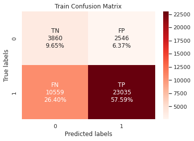

```python
#code from: https://medium.com/@dtuk81/confusion-matrix-visualization-fc31e3f30fea
#code from: https://stackoverflow.com/questions/19233771/sklearn-plot-confusion-matrix-with-labels/19252430

print("Train confusion matrix")

conf_matr_train_set1 = confusion_matrix(y_train, predict(y_train_pred_set1, tr_thresholds1,train_fpr1, train_tpr1))
print(conf_matr_train_set1)
print("="*100)
group_names = ["TN","FP","FN","TP"] #labels of actual and predicted values(each quadrant)
group_counts = ["{0:0.0f}".format(value) for value in conf_matr_train_set1.flatten()]

#percentage of data is represented in each quadrant
group_percentages = ["{0:.2%}".format(value) for value in conf_matr_train_set1.flatten()/np.sum(conf_matr_train_set1)]

labels = [f"{v1}\n{v2}\n{v3}" for v1, v2, v3 in zip(group_names,group_counts,group_percentages)]
labels = np.asarray(labels).reshape(2,2)
ax= plt.subplot()
sns.heatmap(conf_matr_train_set1, annot=labels, fmt='',cmap='Reds',ax=ax)

ax.set_xlabel('Predicted labels');ax.set_ylabel('True labels');
ax.set_title('Train Confusion Matrix');
ax.xaxis.set_ticklabels(['0', '1']); ax.yaxis.set_ticklabels(['0', '1']);
ax.set_xlabel('Predicted labels');ax.set_ylabel('True labels');
```

### Confusion Matrix: x_test_set1

```
Test confusion matrix
the maximum value of tpr*(1-fpr) 0.30850093022138575 for threshold 0.502
[[1236  365]
 [5397 3002]]
====================================================================================================
```

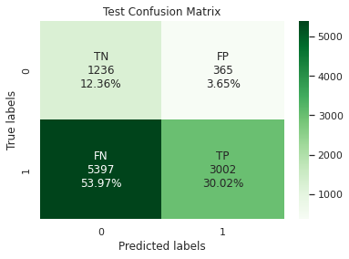

```python
print("Test confusion matrix")

conf_matr_test_set1 = confusion_matrix(y_test, predict(y_test_pred_set1, tr_thresholds1, test_fpr1, test_tpr1))
print(conf_matr_test_set1)
print("="*100)
group_names = ["TN","FP","FN","TP"] #labels of actual and predicted values(each quadrant)
group_counts = ["{0:0.0f}".format(value) for value in conf_matr_test_set1.flatten()]

#percentage of data is represented in each quadrant
group_percentages = ["{0:.2%}".format(value) for value in conf_matr_test_set1.flatten()/np.sum(conf_matr_test_set1)]

labels = [f"{v1}\n{v2}\n{v3}" for v1, v2, v3 in zip(group_names,group_counts,group_percentages)]
labels = np.asarray(labels).reshape(2,2)
ax= plt.subplot()
sns.heatmap(conf_matr_test_set1, annot=labels, fmt='',cmap='Greens',ax=ax)

ax.set_xlabel('Predicted labels');ax.set_ylabel('True labels');
ax.set_title('Test Confusion Matrix');
ax.xaxis.set_ticklabels(['0', '1']); ax.yaxis.set_ticklabels(['0', '1']);
ax.set_xlabel('Predicted labels');ax.set_ylabel('True labels');
```

```python
from xgboost import XGBClassifier
from sklearn.metrics import roc_curve
from sklearn.model_selection import GridSearchCV
import matplotlib.pyplot as plt
from sklearn.metrics import roc_auc_score


xgb_clf_set2 = XGBClassifier()

parameters = { 'max_depth':[5,10],'eta':[0.0001, 0.001, 0.01, 0.1],'n_estimators': [30, 40, 50]}

clf2 = GridSearchCV(xgb_clf_set2, parameters, cv=3, scoring='roc_auc', verbose=1,return_train_score=True,n_jobs=-1)

clf2.fit(x_train_set2, y_train)


train_auc= clf2.cv_results_['mean_train_score']
train_auc_std= clf2.cv_results_['std_train_score']
cv_auc = clf2.cv_results_['mean_test_score']
cv_auc_std= clf2.cv_results_['std_test_score']

bestMaxdepth_2=clf2.best_params_['max_depth']
bestLearningRate_2 = clf2.best_params_['eta']
best_n_estimator_2 =clf2.best_params_['n_estimators']


print("BEST MAX DEPTH: ",bestMaxdepth_2)
print("BEST MIN SAMPLES SPLIT:",bestLearningRate_2)
print("BEST n_estimator: ",best_n_estimator_2)
```

```
Fitting 3 folds for each of 24 candidates, totalling 72 fits
```

```
[Parallel(n_jobs=-1)]: Using backend LokyBackend with 2 concurrent workers.
[Parallel(n_jobs=-1)]: Done  46 tasks      | elapsed: 37.2min
[Parallel(n_jobs=-1)]: Done  72 out of  72 | elapsed: 61.4min finished
```

```
BEST MAX DEPTH:  5
BEST MIN SAMPLES SPLIT: 0.0001
BEST n_estimator:  50
```

```python
#AUC Matrix:set2

learning_rates = [0.0001, 0.001, 0.01, 0.1, 0.2]
n_estimators = [30, 40, 50, 60]

def get_auc_matrix(x_train, x_test, y_train, y_test ):

    train_auc_final_arr, test_auc_final_arr = [], []

    for l_rate in tqdm(learning_rates):
        train_auc_batch, test_auc_batch = [], []

        for num in n_estimators:
            # Below gives large number of warnings
            # xgb_clf = XGBClassifier(n_estimators=num, eta=l_rate, reg_alpha=0, reg_lambda=0, tree_method='gpu_hist')

            # below works after including eval_metric='mlogloss'
            # xgb_clf = XGBClassifier(n_estimators=num, eval_metric='mlogloss', learning_rate=l_rate, reg_alpha=0, reg_lambda=0, tree_method='gpu_hist')

            # Only changing the name of the parameter learning_rate to eta
            xgb_clf = XGBClassifier(n_estimators=num,eta=l_rate)

            xgb_clf.fit(x_train, y_train)

            # I have to predict probabilities (clf.predict_proba) instead of classes for calculating of ROC AUC score:
            y_train_predicted = xgb_clf.predict_proba(x_train)[:, 1]
            y_test_predicted = xgb_clf.predict_proba(x_test)[:, 1]

            train_auc = roc_auc_score(y_train, y_train_predicted)
            test_auc = roc_auc_score(y_test, y_test_predicted)

            train_auc_batch.append(train_auc)
            test_auc_batch.append(test_auc)

        train_auc_final_arr.append(train_auc_batch)
        test_auc_final_arr.append(test_auc_batch)

    return train_auc_final_arr, test_auc_final_arr



train_auc_final_arr_s2, test_auc_final_arr_s2 = get_auc_matrix(x_train_set2, x_test_set2, y_train, y_test)
```

### Heatmap :SET2

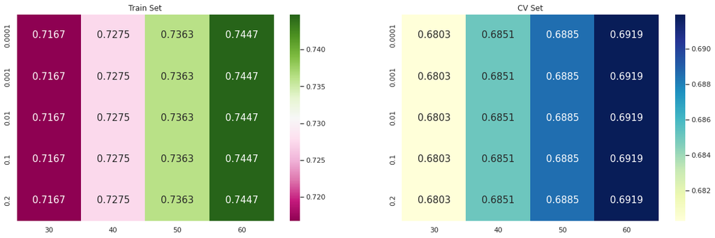

```python
import seaborn as sns; sns.set()
train_auc_final_df_s2 = pd.DataFrame(train_auc_final_arr_s2, columns=n_estimators, index=learning_rates)
test_auc_final_df_s2 = pd.DataFrame(test_auc_final_arr_s2, columns=n_estimators, index=learning_rates)
fig, ax = plt.subplots(1,2, figsize=(20,6))
sns.heatmap(train_auc_final_df_s2, annot = True, fmt='.4g', ax=ax[0],annot_kws={"size": 15},cmap="PiYG")
sns.heatmap(test_auc_final_df_s2, annot = True, fmt='.4g', ax=ax[1],annot_kws={"size": 15},cmap="YlGnBu")
ax[0].set_title('Train Set')
ax[1].set_title('CV Set')
plt.show()
```

### ROC Curve

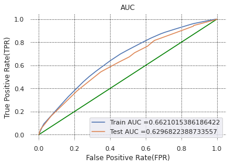

```python
xgb_clf2 = XGBClassifier(n_estimators=best_n_estimator_2 , learning_rate=bestLearningRate_2, max_depth=bestMaxdepth_2)

xgb_clf2.fit(x_train_set2, y_train)

y_train_pred_set2=xgb_clf2.predict_proba(x_train_set2)[:,1]
predictions_train_set2=xgb_clf2.predict(x_train_set2)

y_test_pred_set2=xgb_clf2.predict_proba(x_test_set2)[:,1]
predictions_test_set2=xgb_clf2.predict(x_test_set2)

train_fpr2, train_tpr2, tr_thresholds2 = roc_curve(y_train, y_train_pred_set2)
test_fpr2, test_tpr2, te_thresholds2 = roc_curve(y_test, y_test_pred_set2)

ax = plt.subplot()

auc_set2_train=auc(train_fpr2, train_tpr2)
auc_set2_test=auc(test_fpr2, test_tpr2)

plt.plot([0, 1], [0, 1], color='green')
ax.plot(train_fpr2, train_tpr2, label="Train AUC ="+str(auc(train_fpr2, train_tpr2)))
ax.plot(test_fpr2, test_tpr2, label="Test AUC ="+str(auc(test_fpr2, test_tpr2)))
plt.legend()
plt.xlabel("False Positive Rate(FPR)")
plt.ylabel("True Positive Rate(TPR)")
plt.title("AUC")
plt.grid(b=True, which='major', color='k', linestyle=':')
ax.set_facecolor("white")
plt.show()
```

### Confusion Matrix: x_train_set2

```
Train confusion matrix
the maximum value of tpr*(1-fpr) 0.3834030618620458 for threshold 0.502
[[ 3816  2590]
 [11972 21622]]
====================================================================================================
```

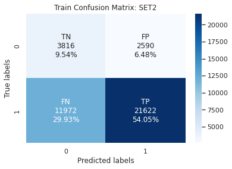

```python
print("Train confusion matrix")

conf_matr_train2 = confusion_matrix(y_train, predict(y_train_pred_set2, tr_thresholds2,train_fpr2, train_tpr2))
print(conf_matr_train2)
print("="*100)
group_names = ["TN","FP","FN","TP"] #labels of actual and predicted values(each quadrant)
group_counts = ["{0:0.0f}".format(value) for value in conf_matr_train2.flatten()]

#percentage of data is represented in each quadrant
group_percentages = ["{0:.2%}".format(value) for value in conf_matr_train2.flatten()/np.sum(conf_matr_train2)]

labels = [f"{v1}\n{v2}\n{v3}" for v1, v2, v3 in zip(group_names,group_counts,group_percentages)]
labels = np.asarray(labels).reshape(2,2)
ax= plt.subplot()
sns.heatmap(conf_matr_train2, annot=labels, fmt='',cmap='Blues',ax=ax)

ax.set_xlabel('Predicted labels');ax.set_ylabel('True labels');
ax.set_title('Train Confusion Matrix: SET2');
ax.xaxis.set_ticklabels(['0', '1']); ax.yaxis.set_ticklabels(['0', '1']);
ax.set_xlabel('Predicted labels');ax.set_ylabel('True labels');
```

### Confusion Matrix: x_test_set2

```
Test confusion matrix
the maximum value of tpr*(1-fpr) 0.3543430670749224 for threshold 0.502
[[1028  573]
 [3764 4635]]
====================================================================================================
```

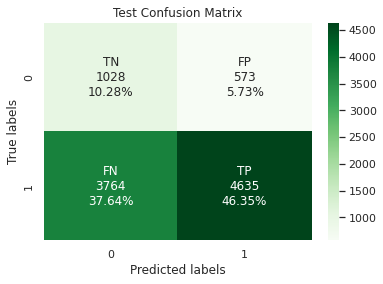

```python
#code from: https://medium.com/@dtuk81/confusion-matrix-visualization-fc31e3f30fea
#code from: https://stackoverflow.com/questions/19233771/sklearn-plot-confusion-matrix-with-labels/19252430

print("Test confusion matrix")

conf_matr_test2 = confusion_matrix(y_test, predict(y_test_pred_set2, tr_thresholds2, test_fpr2, test_tpr2))
print(conf_matr_test2)
print("="*100)
group_names = ["TN","FP","FN","TP"] #labels of actual and predicted values(each quadrant)
group_counts = ["{0:0.0f}".format(value) for value in conf_matr_test2.flatten()]

#percentage of data is represented in each quadrant
group_percentages = ["{0:.2%}".format(value) for value in conf_matr_test2.flatten()/np.sum(conf_matr_test2)]

labels = [f"{v1}\n{v2}\n{v3}" for v1, v2, v3 in zip(group_names,group_counts,group_percentages)]
labels = np.asarray(labels).reshape(2,2)
ax= plt.subplot()
sns.heatmap(conf_matr_test2, annot=labels, fmt='',cmap='Greens',ax=ax)

ax.set_xlabel('Predicted labels');ax.set_ylabel('True labels');
ax.set_title('Test Confusion Matrix');
ax.xaxis.set_ticklabels(['0', '1']); ax.yaxis.set_ticklabels(['0', '1']);
ax.set_xlabel('Predicted labels');ax.set_ylabel('True labels');
```

## 2. Summary:

```python
from prettytable import PrettyTable

x = PrettyTable()

x.field_names = ["Vectorizer", "Model", "n_estimators","Max Dept", "Train AUC", "Test AUC"]

x.add_row(["TF-IDF", "GBDT", best_n_estimator,bestMaxdepth_1,auc_set1_train,auc_set1_test])
x.add_row(["TFIDF_W2V", "GBDT", best_n_estimator_2,bestMaxdepth_2,auc_set2_train,auc_set2_test])

print(x)
```

```
+------------+-------+--------------+----------+--------------------+--------------------+
| Vectorizer | Model | n_estimators | Max Dept |     Train AUC      |      Test AUC      |
+------------+-------+--------------+----------+--------------------+--------------------+
|   TF-IDF   |  GBDT |      50      |    10    | 0.7035803479171896 | 0.6053859732714084 |
| TFIDF_W2V  |  GBDT |      50      |    5     | 0.6621015386186422 | 0.6296822388733557 |
+------------+-------+--------------+----------+--------------------+--------------------+
```

### Reference

- https://www.kaggle.com/paulrohan2020/xgboost-on-donor-choose#XGBoost-on-Donor-Choose
- https://www.kaggle.com/rohit0812/rf-gbdt-on-donor-s-choose-data-set
- https://www.appliedaicourse.com/course/11/Applied-Machine-learning-course